# Explore White Wine Quality

Let us determine the relationship if any present between total acidity, citric acid, sweetness and wine rating

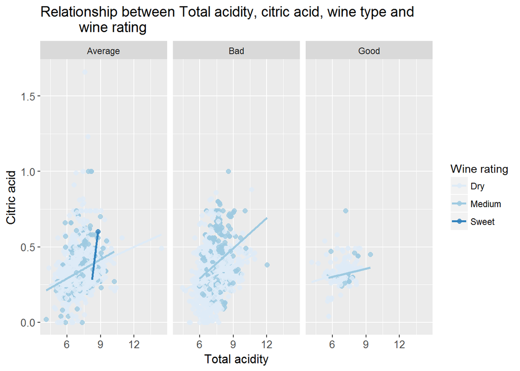

This plot explores the relationship between citric and total acidity wrt to sweetness and wine rating. Here for good wines, a very small proportion is medium sweet and else are normally dry. The citric acid proportion also is less. For bad wines, high percentage of wines are dry followed by medium wines. The citric acid level is high as compared to good wines.

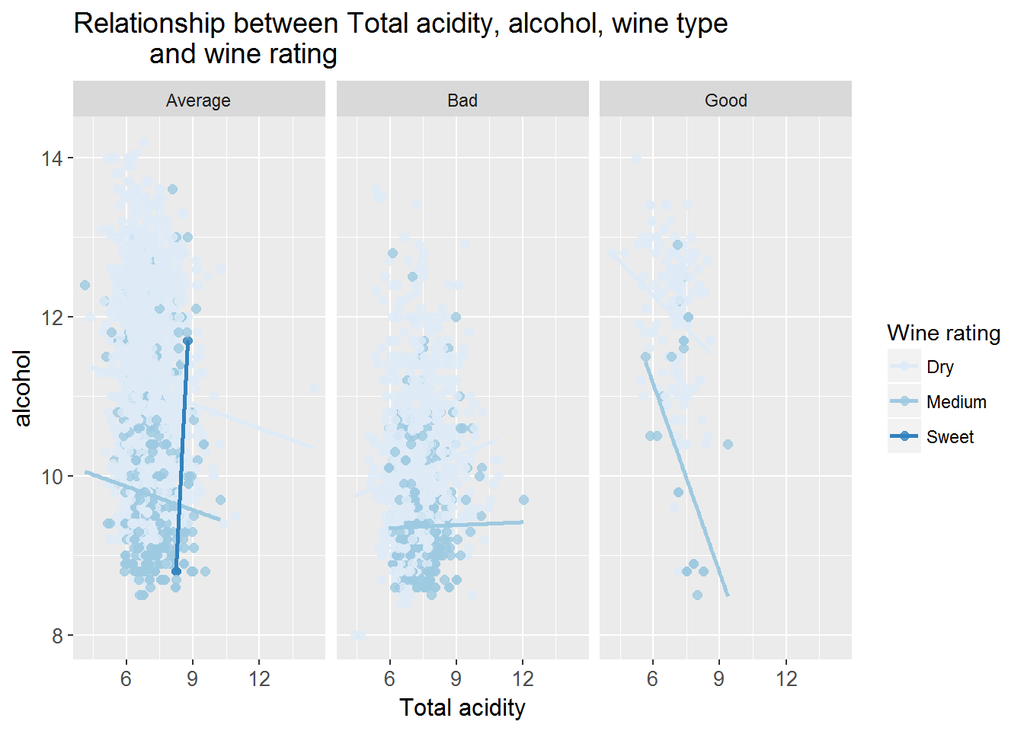

This plot explores the relationship between total acidity and alcohol wrt to wine sweetness and rating. A very low proportion falls into “good” wine category followed by bad rating. Good and bad wines have medium/dry level of sweetness with alcohol in the range 8-14.

Today, the use of sulfur dioxide (SO2) is widely accepted as a useful winemaking aide. It is used as a preservative because of its anti-oxidative and anti-microbial properties in wine. Let us explore this relationship with wrt to ph, sugar and wine rating.

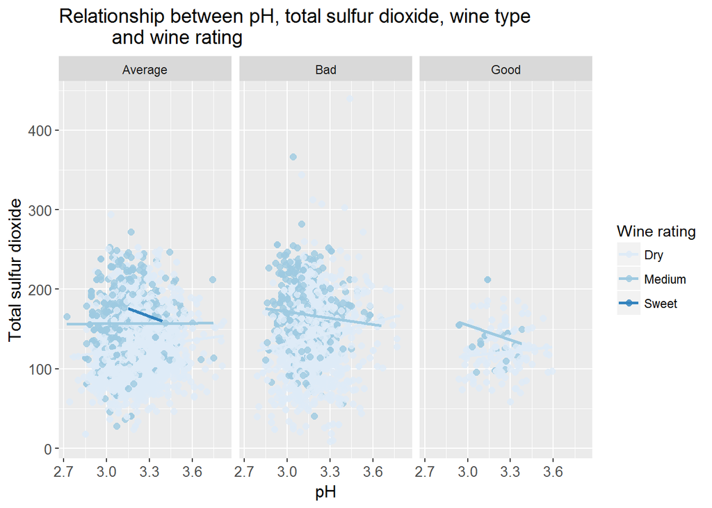

This plot explores the relationship between pH and total sulfur dioxide wrt to sweetness and wine rating. Here the good wines have average count of total sulfur dioixe with dry/medium level of sweetness. The bad wines have large number of dry wines with scattered pH and high total sulfur dioxide.

Let us explore a relationship between sugar level/ chloride sulphate ratio, alcohol level and how it impacts the wine rating

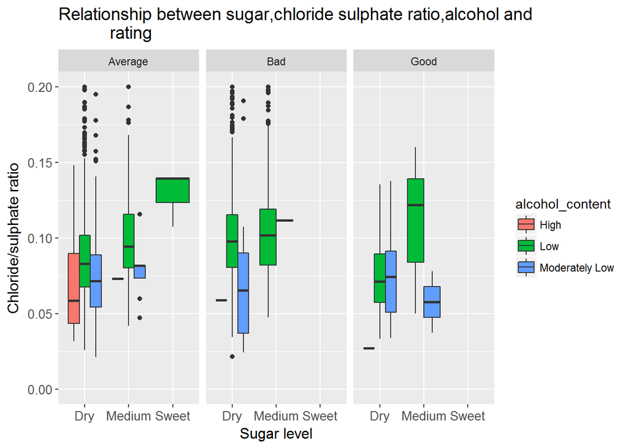

# Multivariate Analysis

### Talk about some of the relationships you observed in this part of the investigation. Were there features that strengthened each other in terms of looking at your feature(s) of interest?

In this part of investigation, I explored relationship among multiple variables int the data set. I found that as sugar content increases in wine, the density increases linearly and the wine quality decreases.Also high rated wines have lower proportion of free v/s total sulfur dioxide proportion as compared to poor rated wines.As total acid density increases in wine the quality decreases, average rated wines are more dry as compared to bad wines which are more mediumly sweeted.Good rated wines have more balance of total acidity with citric acid ratio, dry wines have normally moderately low level of alcohol with high total acidity and medium level of citric acid. Dry wines have normally moderately low level of alcohol and low/medium level of  
citric acid. Medium sweeted wines also have moderately low level of alchol with large number of wines containing medium level of citric acid. From my analysis I cannot pin point a single variable which could directly impact the quality, as they say its more about balance! It has to be a balance of acidity, sweetness, alcohol and sugar.

### Were there any interesting or surprising interactions between features?

# Final Plots and Summary

### Plot One

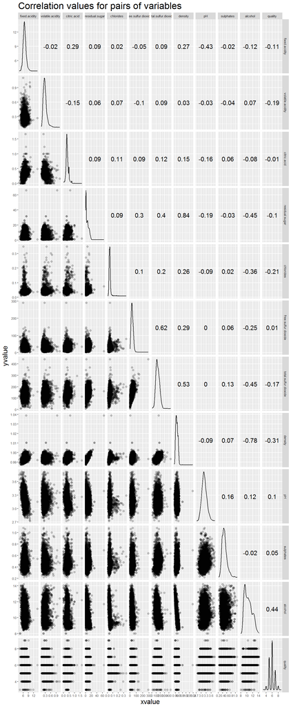

### Description One

This plot shows the correlation among the various variables in the dataset with the alcohol level having the highest level of correlation with the wine quality which have individually been plotted in section 2- Bivariate relationships.

### Plot Two

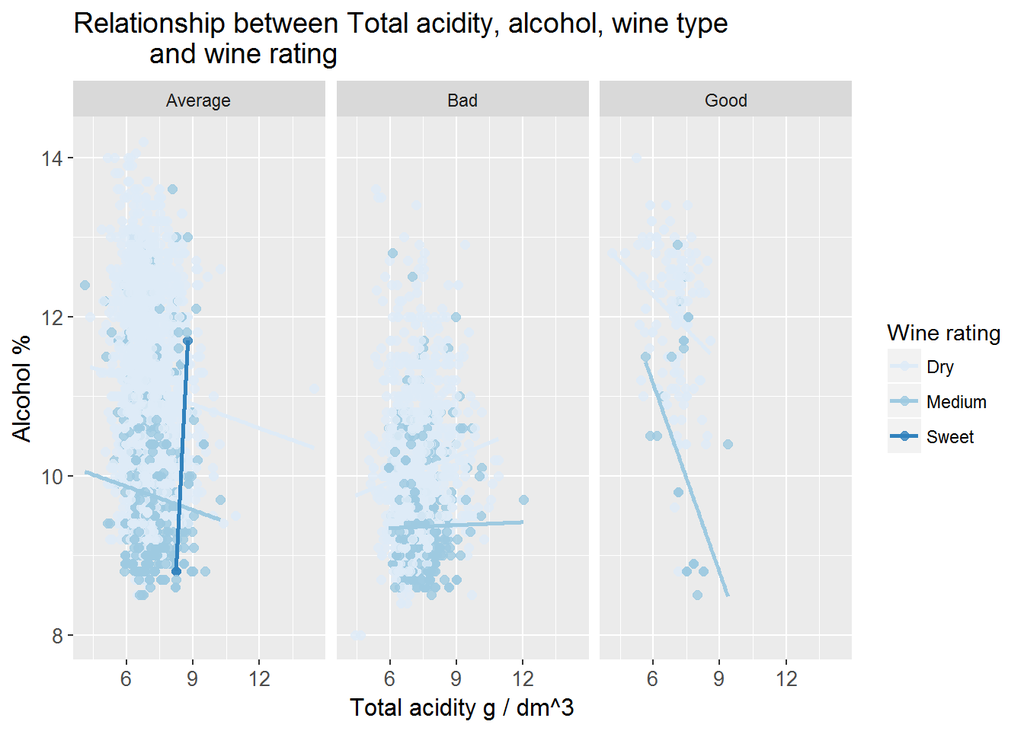

### Plot Three

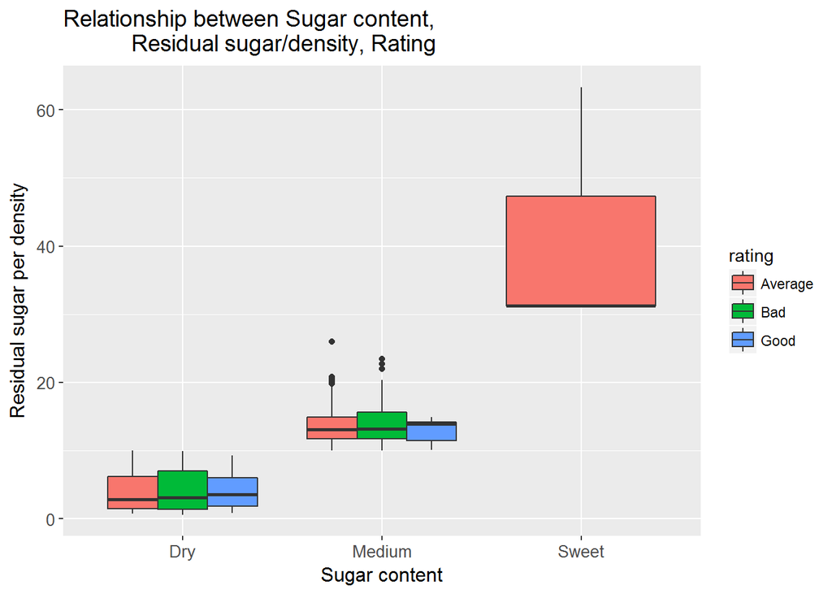

### Description Three

This plot explores the relationship between residual sugar wrt to residual sugar per density and how it impacts the wine rating. It shows that as sweetness level of wines increase, the density as well increases. And it shows that sweet wines have higher sugar/density and are just averagely rated while the dry wines have low sugar/density and are either/average/good rated.

# Reflection

In this project I explored the white wine dataset which contained information about 4898 wines for 13 variables i.e X,fixed.acidity,volatile.acidity, citric.acid, residual.sugar,chlorides,free.sulfur.dioxide,total.sulfur.dioxide, density,pH,sulphates,alcohol,quality. I did exploratory analysis on the data set for single, two and multiple variables in the dataset using R plots/visualizations.

In the first section of univariate analysis, I plotted the distribution of each of the data set to better understand the sample data of white wines. I created some additional variables such as rating based upon the wine quality,total acidity which was the sum of fixed and variable acidity, wine type which determined the sugar level of the wines, grouped total sulfur dioxide and citric acid proportion into various buckets and chloride sulphate ratio.

Certain variables like fixed acidity,chloride and alcohol variables had to be log transformed to make the plot more normally distributed. Other than that citric acid, sulfur dioxide and residual sugar plots x- axis had to be re-adjusted to have a better understanding of the visualization.

The road-block which I hit in this exercise was choosing the dataset. Initially I was keen on exploring the presidential election dataset and was half way through as well, but I hit a road block in between in the bivariate section where I could not establish correlation among the categorical variables in the section. So I thought of switching to the wine dataset. This was also not a smooth sailing for me as I could not establish a strong correlation among the variables in the multi variate section which directly influenced the wine quality. So I read couple of articles in the Internet to better understand wine preperation and the significance of various chemical constituents and then I was able to move forward in my exploration.

Coming back to the white wine data set, I feel additional research about the data set needs to be carried out considering other factors as well. Because there can be other non chemical factors like location,topography,soil,climate, temperature which might influence the wine preperation and hence impact the wine quality.Future scope includes creation of a linear predictive model for wine analysis.